# Прыжок из стратосферы

[figure not shown]

В 2012 году в рамках проекта [Red Bull Stratos](https://en.wikipedia.org/wiki/Red_Bull_Stratos) скайдайвер Феликс Баумгартнер выполнил прыжок из стратосферы с высоты 38 969 метров. В свободном падении перед раскрытием парашюта он провел 4 минуты 20 секунд и во время прыжка преодолел звуковой барьер, став первым человеком, совершившим это без двигателя. Звук преодоления звукового барьера был [зафиксирован](https://www.youtube.com/watch?v=yZFz6y4UCuo) с поверхности Земли примерно в 75 км от центра управления.

Известно, что масса Феликса составляет 73 кг, а масса скафандра и шлема — [32 кг](https://www.azom.com/article.aspx?ArticleID=7576). Точное значение массы во время прыжка неизвестно, однако некоторые исследователи (10.1371/journal.pone.0187798) используют значение 121 кг.

В момент прыжка температура окружающей среды составляла [минус 70.9 °C](https://www.redbull.com/int-en/projects/red-bull-stratos), при этом температура в месте приземления была около [14 °C](https://en.wikipedia.org/wiki/Red_Bull_Stratos).

Финальный научный отчёт о прыжке не содержит полных данных о скорости и высоте на протяжении всего прыжка, но поскольку [весь прыжок был записан](https://www.redbull.com/int-en/videos/multi-angle-views-with-mission-data-mission-to-the-edge-of-space-gopro-extra), энтузиасты извлекли данные из трансляции. Ниже приведены данные, которые необходимо использовать для верификации моделей.

# Постановка задачи

На основе второго закона Ньютона и с применением нескольких циклов математического моделирования рассмотрите свободный прыжок Феликса до раскрытия парашюта. Рассмотрите следующие модели:

1. Из приведённых ниже данных известно, что в последние 500 метров свободного падения скорость Феликса на высоте примерно 2.5–3 км не менялась и составляла около 56.4 м/с. Убедитесь, что при фиксированной плотности воздуха в созданной Вами модели правильно подобран коэффициент сопротивления формы, и парашютист достигает предельной скорости.
2. Используя данные о температуре и локации прыжка, добавьте в модель изменение плотности воздуха, которая убывает экспоненциально с ростом высоты. Обоснуйте выбранные значения. Сравните результаты изменения скорости и высоты, получаемые с помощью Вашей модели, с реальными данными. Выполните сравнение графически и предоставьте анализ с использованием методов описательной статистики. Например, можно использовать коэффициенты корреляции Пирсона, Спирмена, Кендалла, коэффициент детерминации $R^{2}$, RMSE, MAE и т.д. Обоснуйте выбор применённых методов.
3. Максимально дополните Вашу модель. Например, известно, что значение коэффициента сопротивления формы зависит от положения тела во время падения: головой вниз или в горизонтальном положении (животом вниз). На записи видно, что в прыжке присутствуют оба варианта. Сравните разработанную модель с предыдущей и с данными реального прыжка.

**Какая из построенных моделей продемонстрировала наибольшую положительную корреляцию по выбранным методам описательной статистики?**

# Примечания

- Обратите внимание, что значение ускорения свободного падения во время прыжка изменялось, поскольку на высоте 39 км оно немного меньше, чем на поверхности Земли. Для определения значения можно использовать формулу WGS-84 (эллипсоидальная формула гравитации) для расчёта ускорения *на поверхности Земли* в зависимости от географической широты или формулу FAC (Free-Air Correction, поправочный коэффициент высоты). Также возможно [применение](https://doi.org/10.1371/journal.pone.0187798) комбинации этих формул.

## Данные прыжка

Доступны [по ссылке](https://github.com/poluyan/msuode/blob/main/jump.dat) или в виде кода ниже. Для верификации моделей используйте эти данные.

**Обратите внимание, что шаг по времени различный. Будьте внимательны при применении методов описательной статистики.**

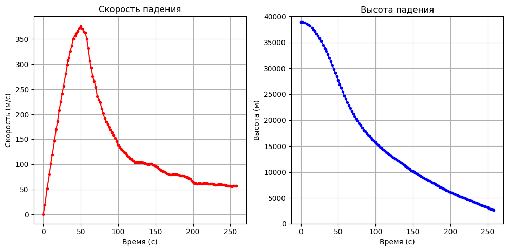

```python
import matplotlib.pyplot as plt

time = [
    0, 2, 5, 8, 10, 12, 15, 17, 19, 21, 23, 25, 27, 30, 32, 33, 34, 36, 38, 40,
    42, 44, 46, 48, 50, 52, 54, 56, 58, 60, 62, 64, 66, 68, 70, 72, 74, 76, 78, 80,
    82, 84, 86, 88, 90, 92, 94, 96, 98, 100, 102, 104, 106, 108, 110, 112, 114,
    116, 118, 120, 122, 124, 126, 128, 130, 132, 134, 136, 138, 140, 142, 144,
    146, 148, 150, 152, 154, 156, 158, 160, 162, 164, 166, 168, 170, 172, 174,
    176, 178, 180, 182, 184, 186, 188, 190, 192, 194, 196, 198, 200, 202, 204,
    206, 208, 210, 212, 214, 216, 218, 220, 222, 224, 226, 228, 230, 232, 234,
    236, 238, 240, 242, 244, 246, 248, 250, 252, 254, 256, 258
]

velocity = [
    0, 18.6, 51.9, 79.7, 101.1, 119.4, 147.2, 170, 186.1, 208.1, 224.4, 240.6,
    256.7, 281.4, 298.9, 307.5, 312.8, 326.1, 336.7, 350, 356.9, 361.4, 365.8,
    372.2, 376.4, 370.6, 365, 363.1, 350.3, 332.2, 306.7, 293.3, 275.8, 265.8,
    254.7, 236.1, 228.3, 223.1, 211.7, 201.7, 191.7, 184.7, 179.7, 174.2, 169.7,
    164.4, 157.8, 152.2, 146.1, 138.9, 134.7, 130.6, 126.9, 124.2, 122.2, 118.6,
    115.3, 111.9, 109.4, 107.2, 104.2, 103.3, 103.9, 104.2, 104.2, 103.6, 103.1,
    101.9, 100.3, 99.7, 99.4, 100.3, 98.6, 97.5, 96.4, 94.2, 91.4, 89.4, 86.9,
    86.7, 85.6, 82.8, 81.4, 80.6, 79.4, 80.3, 80.3, 80.3, 80.3, 79.2, 78.3, 77.5,
    77.5, 77.5, 75.3, 73.6, 71.9, 70.6, 66.9, 63.6, 61.4, 61.9, 61.1, 62.2, 61.4,
    61.1, 61.7, 61.4, 61.4, 60.8, 60.6, 60.6, 60.3, 59.7, 59.2, 58.9, 59.7, 59.4,
    59.7, 58.3, 58.3, 57.8, 56.9, 56.7, 56.4, 55.3, 56.4, 56.4, 56.4
]

altitude = [
    38969, 38948, 38827, 38635, 38439, 38233, 37842, 37471, 37175, 36715, 36274,
    35797, 35306, 34487, 33919, 33661, 33340, 32676, 32002, 31326, 30642, 29884,
    29183, 28448, 27710, 26883, 26250, 25454, 24746, 24112, 23413, 22857, 22307,
    21729, 21268, 20752, 20247, 19840, 19406, 19026, 18587, 18117, 17852, 17527,
    17131, 16853, 16496, 16188, 15991, 15725, 15324, 15096, 14811, 14581, 14328,
    14077, 13838, 13609, 13412, 13179, 12958, 12756, 12547, 12353, 12137, 11928,
    11712, 11513, 11314, 11104, 10912, 10706, 10526, 10308, 10124, 9926, 9744,
    9569, 9389, 9210, 9040, 8872, 8705, 8533, 8393, 8232, 8055, 7915, 7747,
    7589, 7432, 7273, 7112, 6966, 6811, 6665, 6513, 6378, 6218, 6112, 5996,
    5839, 5745, 5609, 5501, 5356, 5245, 5120, 4997, 4876, 4752, 4634, 4509,
    4388, 4273, 4149, 4033, 3915, 3796, 3667, 3570, 3441, 3330, 3213, 3101,
    2989, 2882, 2767, 2651
]

# Построение графиков
fig, (ax1, ax2) = plt.subplots(1, 2, figsize=(10, 5), sharex=True)

ax1.plot(time, velocity, marker='.', color='red')
ax1.set_ylabel('Скорость (м/с)')
ax1.set_xlabel('Время (с)')
ax1.set_title('Скорость падения')
ax1.grid(True)

ax2.plot(time, altitude, marker='.', color='blue')
ax2.set_ylim(0, 40000)
ax2.set_xlabel('Время (с)')
ax2.set_ylabel('Высота (м)')
ax2.set_title('Высота падения')
ax2.grid(True)

plt.tight_layout()
plt.show()
```